# PRACTICA 1 DE BIG DATA

Author

Gayeong Lee, Xavier Varela, Ángela Rodríguez

## INTRODUCCIÓN

Con el fin del parón económico posterior al COVID-19 todos los indicadores mostraban un importante despegue de la economía occidental y, especialmente, la española. Sin embargo, el conflicto armado entre Rusia y Ucrania iniciado en febrero de 2022 no solo ha trastocado las perspectivas de crecimiento de los países europeos, sino que ha sido el desencadenante de una de las mayores crisis inflacionarias de la época. Las consecuencias de esta guerra sobre la economía y sociedad son importantes y, por ello, es un tema de gran interés e importancia para cualquier analista político.

Recientemente se ha hecho de dominio público la filtración de documentos clásificados del Pentágono con información vital sobre los planes y estructuras de los países de la OTAN dentro de Ucrania. Como consideramos este tema importante y aprovechando los recursos que la asignatura de BIG DATA nos brinda, nos hemos planteado investigar el impacto de la filtración de estos documentos en la opinión pública. Más concretamente en Twitter.

Por lo tanto, la pregunta que pretende responder esta primera práctica es sí el tema de las filtraciones ha sido relevante dentro de la plataforma twitter.

## LIBRERIAS

```r
library(rtweet)
library(tidyverse)
library(dplyr)
library(wordcloud)
library(RColorBrewer)
require(tm)
library(syuzhet)
```

## ARCHIVOS

```r
load(file="./tweets_GAYEONG_filtraciones.RData")
load(file="./users_GAYEONG_filtraciones.RData")
```

## 1-1. Identificar los hashtags más populares (top 5) que se hayan utilizado

```r
tweets <- tweets %>%
  mutate(hashtags=str_extract_all(text, "#\\S+"))

table(unlist(tweets$hashtags)) %>% as.data.frame() %>% slice_max(Freq,n=5)
```

```
           Var1 Freq
1    #Pentágono  272
2    #Pentagono  124
3         #EEUU  121
4   #documentos   97
5 #JackTeixeira   79
```

```r
# Este código ha sido extraido de las diapositivas de clase
```

## 1-2. Identificar los tweets más populares (top 5) que se hayan retuiteado

```r
tweets <- tweets %>%
  mutate (screen_name = users$screen_name)

tweets %>%
  slice_max(retweet_count, n=5) %>%
  select(text, retweet_count, screen_name)
```

```
# A tibble: 5 × 3
  text                                                           retwe…¹ scree…²
  <chr>                                                            <int> <chr>
1 "\U0001f1fa\U0001f1f8 | URGENTE: El FBI arrestó al filtrador …     776 Alerta…
2 "El Presidente no lo tiene claro pero el Pentágono no filtró …     688 beltra…
3 "Confirmado!\nLos papeles del #Pentagono demuestran que solda…     470 manelm…
4 "⚡ #AHORA | El FBI detiene a Jack Teixeira, un técnico de 21…     460 MundoE…
5 "\U0001f1fa\U0001f1f8 | El fiscal general de Estados Unidos, …     403 MundoE…
# … with abbreviated variable names ¹retweet_count, ²screen_name
```

```
ℹ Users data at users_data()
```

```r
# Este código ha sido extraído parcialmente de las diapositivas de clase y mejorado gracias al apoyo conjunto de otros grupos.
```

Como podemos observar, los twets con más popularidad dentro de la plataforma son los que hablan sobre el presunto filtrador de los documentos, Jack Teixeira, y sus problemas con la justicia norteamericana.

Cuando planteamos este tema, esperabamos encontrar tweets que abordan la información filtrada como los más populares. Sin embargo, el tema más relevante en twitter no es el contenido en sí de los documentos filtrados, sino que es la persona que compartió esta información en redes y su futuro inmediato.

## 1-3. Identificar las cuentas más activas (top 5) que hayan hecho el mayor número de tweets y/o RTs

```r
num_tweets <- users %>%
  count(screen_name, name = "num_tweets") %>%
  arrange(desc(num_tweets)) %>%
  slice_head(n = 5)

num_tweets
```

```
# A tibble: 5 × 2
  screen_name    num_tweets
  <chr>               <int>
1 luiss_teixeira        154
2 Elpoliticonews         44
3 negocios_tv            23
4 yas_teixeira           18
5 CNNEE                  17
```

```r
# Este código lo hemos desarrollado por nuestra cuenta.
```

Los resultados de este segundo código muestran un error relevante en nuestro trabajo. el usuario luiss_teixeira es, con mucha diferencia, la cuenta de twitter que más actividad ha generado sobre el caso. Sin embargo, tras un breve análisis posterior, nos hemos dado cuenta que las cuentas luiss_teixeira y yas_teixeira han sido erroneamente seleccionadas debido a que usan el término “teixeira” en su usario. En el caso del primero, es una cuenta de un seguidor de futbol uruguayo y no aporta ningún tweet al tema que abordamos.

```r
num_tweets <- users %>%
  count(screen_name, name = "num_tweets") %>%
  arrange(desc(num_tweets)) %>%
  slice_head(n = 7)

num_tweets <- num_tweets %>% filter(!row_number() %in% c(1,4))

num_tweets
```

```
# A tibble: 5 × 2
  screen_name    num_tweets
  <chr>               <int>
1 Elpoliticonews         44
2 negocios_tv            23
3 CNNEE                  17
4 ActualidadRT           14
5 la_patilla             13
```

Teniendo en cuenta el problema anterior, hemos elaborado un código que eliminaba a los dos usarios que compartian nombre con Jack Teixeira y estaban erroneamente incluidos como personas que habían participado activamente. Así que estos 5 usarios, todos ellos cuentas de twitter dedicadas a la información, han sido las más activas sobre el tema.

Nos hubiera gustado encontrarnos algún usuario relevante dentro de la plataforma, que no fuese un medio de información, tratando el tema y siendo influyente en la conversación.

## 1-4. Identificar las cuentas más populares (top 5) que tengan mayor número de seguidores

```r
users %>% select(screen_name,followers_count) %>%
  distinct() %>% slice_max(followers_count,n=6)
```

```
# A tibble: 6 × 2
  screen_name     followers_count
  <chr>                     <int>
1 CNNEE                  22417108
2 AristeguiOnline         9470688
3 el_pais                 8750515
4 el_pais                 8750514
5 lopezdoriga             8099148
6 la_patilla              7542403
```

```r
# Este código lo hemos extraído de las diapostivas de clase
```

En línea con lo menciado anteriormente, las cuentas que han tratado el tema de la filtración de documentos y que más relevancia dentro de twitter son, en su totalidad, medios de comunicación. La única excepción podrían ser los usarios AristeguiOnline y lopezdoriga, ya que no son un grupo, empresa u asociación informativo, sino que son individuos individuales. Sin embargo, en la cuenta de AristeguiOnline no solo escribe la propia Aristegui, sino que tiene un equipo de trabajadores que se encargan de publicar ciertas informaciones determinadas, por lo que en términos prácticos sería tambien una asociación/grupo de periodistas.

## 2-1. Construir la nube de palabras para todos los tweets, los de sentimiento más positivo y más negativo

```r
#Para la construcción de toda la nube nos hemos servido del código de las diapositivas.

texts <- tweets$text
```

#### Eliminamos

- Emojis, end-of-line, spaces.
- Retweets, mentions, html links.
- Punctuation, numbers, etc.
- Line breaks

```r
texts <- iconv(texts,"UTF-8","latin1",sub=" ")
texts <- gsub("(RT|via)((?:\\b\\W*@\\w+)+)", " ", texts)
texts = gsub("@\\w+", " ", texts)
texts = gsub("[[:punct:]]", " ", texts)
texts = gsub("[[:digit:]]", " ", texts)
texts = gsub("http.*", " ", texts)
texts = gsub("[ \t]{2,}", " ", texts)
texts = gsub("^\\s+|\\s+$", "", texts)
texts = gsub("\n"," ",texts)
```

#### Analizamos la polaridad de tweets

```r
polarity <- get_sentiment(texts,method="nrc",language="spanish")
```

#### Los tweets más positivos

```r
tweets %>% filter(polarity>2) %>% select(text) %>% head(5)
```

```
# A tibble: 5 × 1
  text
  <chr>
1 "El Presidente no lo tiene claro pero el Pentágono no filtró a The Washington…
2 "\U0001f4d6\n.\nUn buen #libro no tiene por qué quedarse entre cientos de #do…
3 "@teixeira_marcao @SevillaFC @EuropaLeague @JonathanXG Q bueno eres coño"
4 "@teixeira_marcao @EuropaLeague @SevillaFC @JonathanXG Ponte bueno pronto mak…
5 "@teixeira_marcao @EuropaLeague @SevillaFC @JonathanXG Ponte bueno, gordi."
```

```
ℹ Users data at users_data()
```

#### Los tweets más negativos

```r
tweets %>% filter(polarity< -2) %>% select(text) %>% head(5)
```

```
# A tibble: 5 × 1
  text
  <chr>
1 "@teixeira_marcao @EuropaLeague @SevillaFC @JonathanXG Espero que lo de ayer …
2 "@teixeira_marcao @EuropaLeague @SevillaFC @JonathanXG Como hincha del United…
3 "@ivangferreira10 Es sabido que Luque le gana muy pocas veces a Guaraní,por q…
4 "@teixeira_marcao @SevillaFC @EuropaLeague @JonathanXG Habla con los entrenad…
5 "@lopezobrador_ ¿ Y Jack Teixeira ? básicamente son filtraciones tambien pero…
```

```
ℹ Users data at users_data()
```

#### Construyemos la nube de palabras

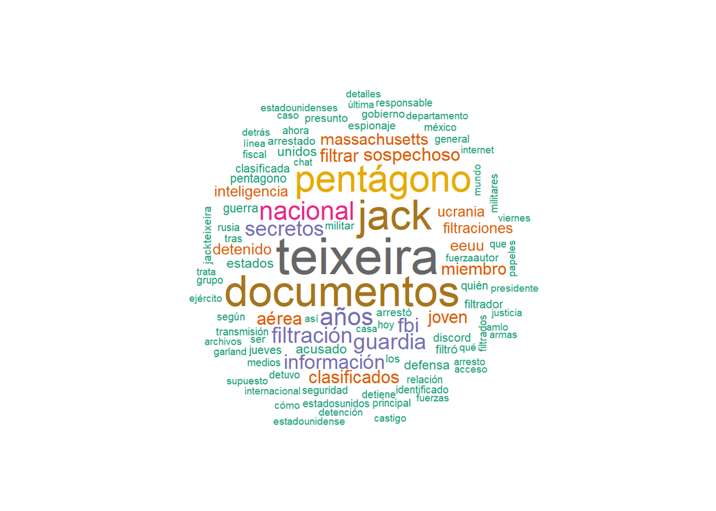

```r
texts <- removeWords(texts, stopwords("spanish"))

corpus.texts.all <- Corpus(VectorSource(texts))
corpus.texts.pos <- Corpus(VectorSource(texts[polarity>0]))
corpus.texts.neg <- Corpus(VectorSource(texts[polarity<0]))

wordcloud(corpus.texts.all, max.words=100, random.order= F, colors=brewer.pal(8,"Dark2"),scale = c(3,.5))
```

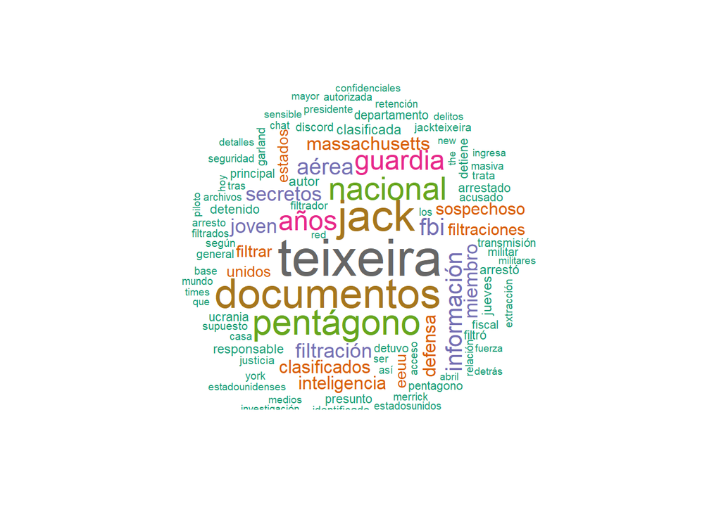

```r
wordcloud(corpus.texts.pos, max.words=100, random.order= F, colors=brewer.pal(8,"Dark2"),scale = c(3,.5))
```

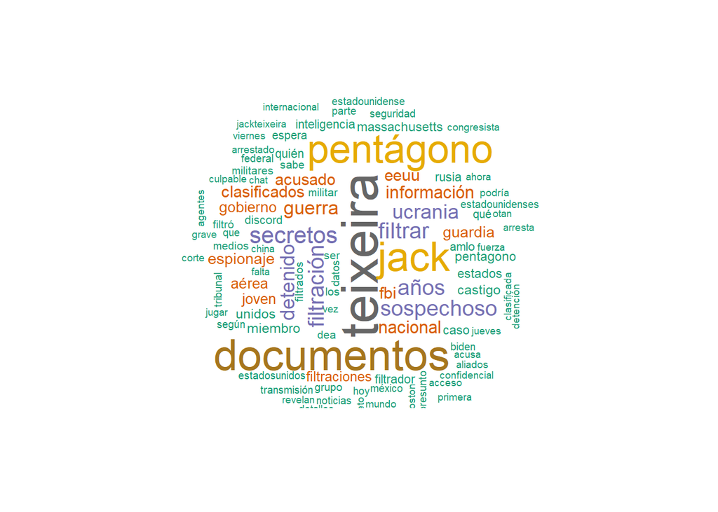

```r
wordcloud(corpus.texts.neg, max.words=100, random.order= F, colors=brewer.pal(8,"Dark2"),scale = c(3,.5))
```

En la nube de palabras nos salen diversos adjetivos relacionados con el tema en cuestión, tanto positivos, como negativos y neutros. Siendo las palabras teixeira, documentos y pentágono las más repetidas. En el caso de Teixeira, consideramos que puede estar sobredimensionada debido al usuario luiss_teixeira que trataba cuestiones de futbol, por lo que ponemos en tela de juicio su tan notaria relevancia.

## CONCLUSIÓN

El objetivo de investigación realizada ha sido el de analizar el impacto de la filtración de documentos clasificados del Pentágono en la opinión pública a través de Twitter. En particular, se busca responder si el tema de las filtraciones ha sido relevante dentro de la plataforma. Para ello, hemos utilizado diversas librerías en R y archivos de tweets y usuarios. Se identifican los hashtags más populares utilizados, los tweets más populares retuiteados, las cuentas más activas y las cuentas más populares con mayor número de seguidores.

Con el analisis de toda esta información podemos concluir que el usuario Jack Teixeira, presunto filtrador de los documentos y sus problemas con la justicia, es el tema más relevante en Twitter. Es decir, los temas de los que hablan estos documentos a penas es comentado en Twiter. Concluimos que los usuarios que han tratado el tema de la filtración de documentos y que tienen mayor relevancia dentro de Twitter son cuentas de información y no usuarios corrientes que conversen sobre estos en esta red social.

Creemos que si la búsqueda la hubieramos hecho con tuits publicados en ingles en vez de en español, el análisis hubiera sido más rico y quizá si hubieramos encontrado conversaciones sobre los diferentes temas de los que hablaban los papeles filtrados.